# nf-core spring survey 2025

### Confidence with nf-core pipelines

Finally to understand if responders were newcomers versus long time members, we asked how confident people felt using nf-core pipelines, with the assumption of more confident people will have been around for a longer time.

```r
data_confidence_score <- data_responses_raw |>
  select(how_confident_are_you_working_with_nf_core_pipelines) |>
  filter(!is.na(how_confident_are_you_working_with_nf_core_pipelines))
```

And generate another histogram.

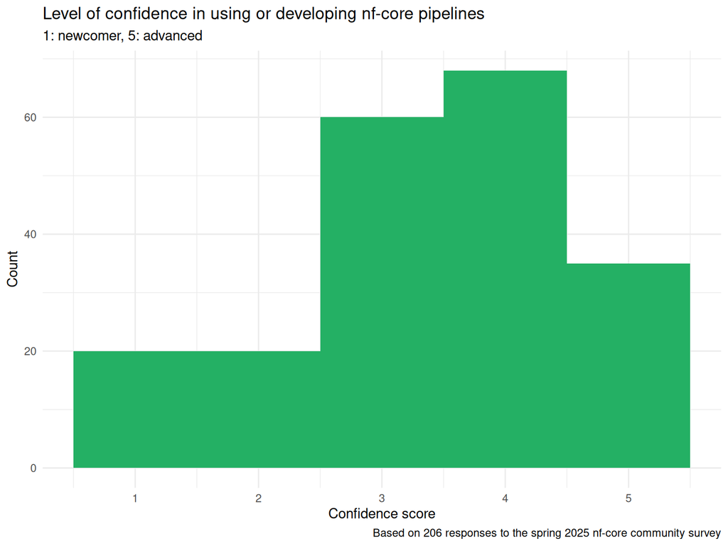

```r
ggplot(
  data_confidence_score,
  aes(how_confident_are_you_working_with_nf_core_pipelines)
) +
  geom_histogram(bins = 5, fill = "#24b064") +
  theme_minimal() +
  labs(title = "Level of confidence in using or developing nf-core pipelines",
     subtitle = "1: newcomer, 5: advanced",
     x = "Confidence score",
     y = "Count",
     caption = paste("Based on", nr_responses, "responses to the spring 2025 nf-core community survey")
)
```

## Feedback - positive and to improve upon

The main questions of the survey - what are you most happy with, what have been your biggest difficulties, and additional feedback/requests - were all free text.

To get a rough overview of the types of responses - i.e., which topics were responders had the biggest issues with - we read through each response and for each of the three questions we assigned one or more tags corresponding to different ‘topics’ the response fell under.

### Data preparation

First we need to load the tags for each response column, split the column tag column per tag, then count the number of times occurs. We do a simple count as a responder may have given multiple bits of feedback.

```r
data_responses_tagged_positive <- data_responses_tagged |> select(positive_tags)
data_responses_tagged_improve <- data_responses_tagged |> select(improvement_tags)
data_responses_tagged_request <- data_responses_tagged |> select(request_tags)

summarise_tag_results <- function(in_list) {
  in_list  |>
    str_split(',') |>
    unlist() |>
    str_trim(side = 'both') |>
    as_tibble_col(column_name = 'topic') |>
    group_by(topic) |>
    summarise(count = n()) |>
    arrange(desc(count)) |>
    mutate(
      topic = fct_reorder(topic, count)
    ) |>
    filter(topic != 'No feedback')

}

data_tags_positive <- summarise_tag_results(data_responses_tagged_positive$positive_tags)

data_tags_improve <- summarise_tag_results(data_responses_tagged_improve$improvement_tags)

data_tags_request <- summarise_tag_results(data_responses_tagged_request$request_tags)
```

We can then plot bar charts with the number of responses hitting a particular topic. Note that remove responses that had no feedback.

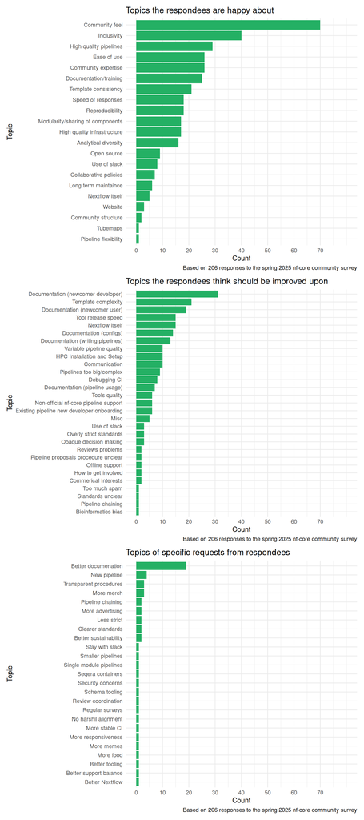

```r
plot_topics_summary <- function(in_data, title) {
  ggplot(in_data, aes(y = topic, x = count)) +
    geom_col(fill = "#24b064") +
    theme_minimal() +
    labs(title = title,
         x = "Count",
         y = "Topic",
         caption = paste("Based on", nr_responses, "responses to the spring 2025 nf-core community survey")
    ) +
    scale_x_continuous(breaks = seq(0, 70, by = 10), limits = c(0,80))
}

plot_topics_summary(data_tags_positive, "Topics the respondees are happy about") /
plot_topics_summary(data_tags_improve, "Topics the respondees think should be improved upon") /
plot_topics_summary(data_tags_request, "Topics of specific requests from respondees")
```